# Clustering Homework

Tomas

October 7, 2016

## Homework Overview

This mini-project is based on the K-Means exercise from ‘R in Action’ Go [here](http://www.r-bloggers.com/k-means-clustering-from-r-in-action/) for the original blog post and solutions.

## Exercise 0:

Install these packages if you don’t have them already

Now load the data and look at the first few rows

```
##   Type Alcohol Malic  Ash Alcalinity Magnesium Phenols Flavanoids
## 1    1   14.23  1.71 2.43       15.6       127    2.80       3.06
## 2    1   13.20  1.78 2.14       11.2       100    2.65       2.76
## 3    1   13.16  2.36 2.67       18.6       101    2.80       3.24
## 4    1   14.37  1.95 2.50       16.8       113    3.85       3.49
## 5    1   13.24  2.59 2.87       21.0       118    2.80       2.69
## 6    1   14.20  1.76 2.45       15.2       112    3.27       3.39
##   Nonflavanoids Proanthocyanins Color  Hue Dilution Proline
## 1          0.28            2.29  5.64 1.04     3.92    1065
## 2          0.26            1.28  4.38 1.05     3.40    1050
## 3          0.30            2.81  5.68 1.03     3.17    1185
## 4          0.24            2.18  7.80 0.86     3.45    1480
## 5          0.39            1.82  4.32 1.04     2.93     735
## 6          0.34            1.97  6.75 1.05     2.85    1450
```

## Exercise 1:

Remove the first column from the data and scale it using the scale() function

```r
wineScale <- scale(wine[-1])
```

Now we’d like to cluster the data using K-Means. How do we decide how many clusters to use if you don’t know that already? We’ll try two methods.

#### Method 1:

A plot of the total within-groups sums of squares against the number of clusters in a K-means solution can be helpful. A bend in the graph can suggest the appropriate number of clusters.

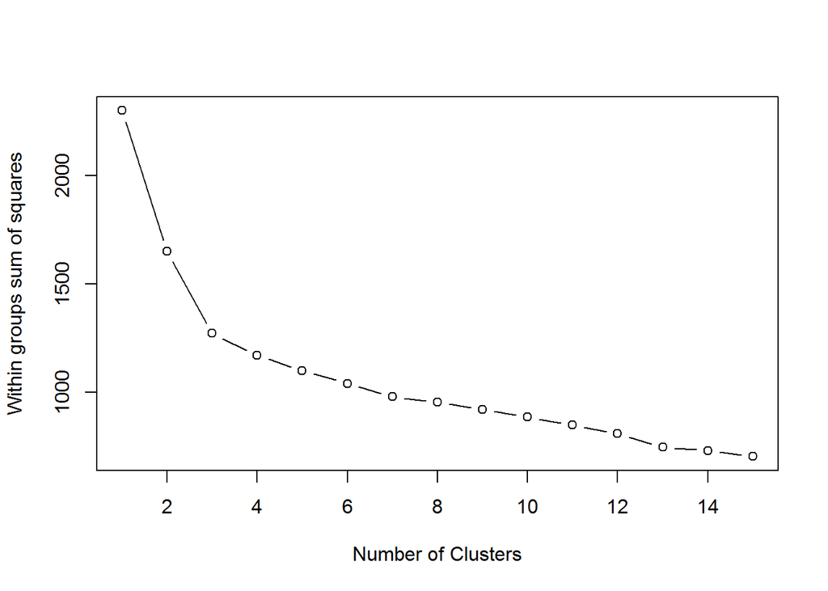

```r
wssplot <- function(data, nc=15, seed=1234){
                  wss <- (nrow(data)-1)*sum(apply(data,2,var))
                      for (i in 2:nc){
                set.seed(seed)
                    wss[i] <- sum(kmeans(data, centers=i)$withinss)}

              plot(1:nc, wss, type="b", xlab="Number of Clusters",
                            ylab="Within groups sum of squares")
       }

wssplot(wineScale)
```

## Exercise 2:

```
* How many clusters does this method suggest?
```

It’s hard to tell for sure, but the plot would seem to suggest about 3 or 4 clusters.

```
* Why does this method work? What's the intuition behind it?
```

We start with the initial outlook on each column, and what the variance is between each category, where this will serve as a baseline if we have only 1 cluster.  
After that, we began calculating the distance between each centroid of the clusters we create, and therefore are able to see how each cluster improves our variance within the model.

```
* Look at the code for wssplot() and figure out how it works
```

#### Method 2:

Use the `NbClust` library, which runs many experiments and gives a distribution of potential number of clusters.

```r
library(NbClust)
set.seed(1234)
nc <- NbClust(wineScale, min.nc=2, max.nc=15, method="kmeans")
```

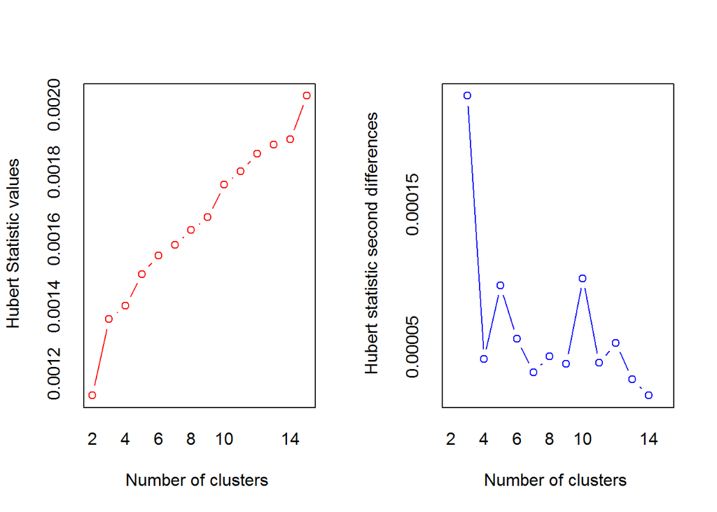

```
## *** : The Hubert index is a graphical method of determining the number of clusters.
##                 In the plot of Hubert index, we seek a significant knee that corresponds to a
##                 significant increase of the value of the measure i.e the significant peak in Hubert
##                 index second differences plot.
##
```

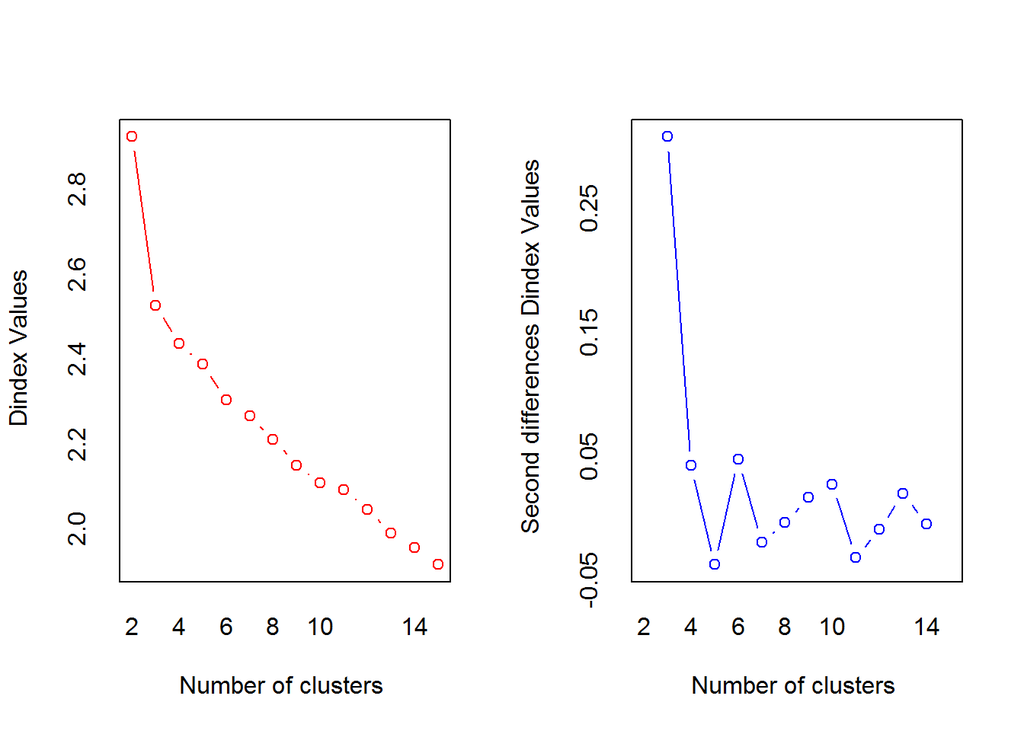

```
## *** : The D index is a graphical method of determining the number of clusters.
##                 In the plot of D index, we seek a significant knee (the significant peak in Dindex
##                 second differences plot) that corresponds to a significant increase of the value of
##                 the measure.
##
## * Among all indices:
## * 4 proposed 2 as the best number of clusters
## * 15 proposed 3 as the best number of clusters
## * 1 proposed 10 as the best number of clusters
## * 1 proposed 12 as the best number of clusters
## * 1 proposed 14 as the best number of clusters
## * 1 proposed 15 as the best number of clusters
##
##                    ***** Conclusion *****
##
## * According to the majority rule, the best number of clusters is  3
##
##
```

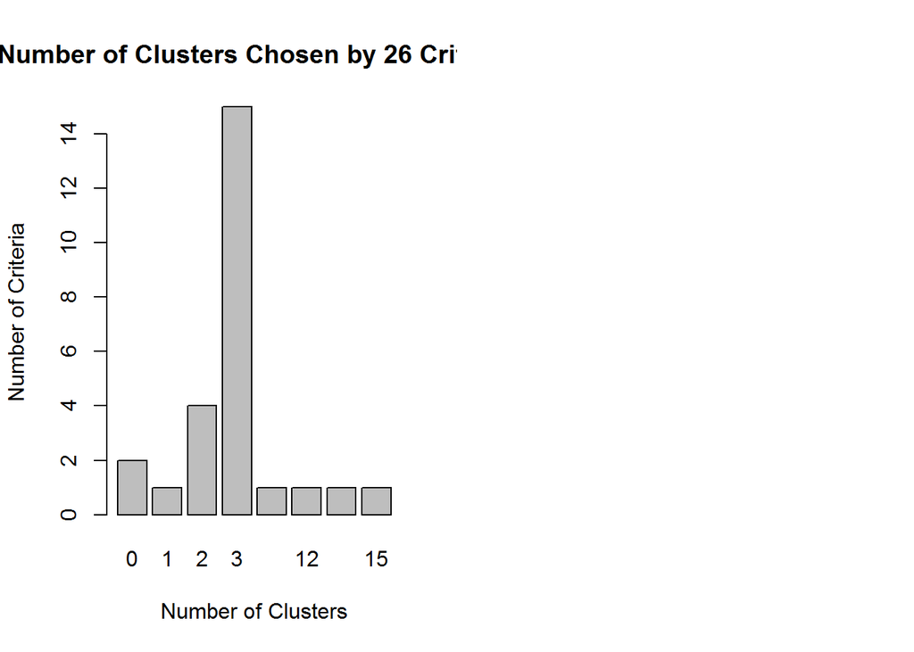

```r
barplot(table(nc$Best.n[1,]),
              xlab="Number of Clusters", ylab="Number of Criteria",
                    main="Number of Clusters Chosen by 26 Criteria")
```

## Exercise 3:

```
* How many clusters does this method suggest?
```

Wells it tells us pretty plainly - 3.

## Exercise 4:

Once you’ve picked the number of clusters, run k-means using this number of clusters. Output the result of calling `kmeans()` into a variable `fit.km`

```r
fit.km <- kmeans(wineScale, 3)
str(fit.km)
```

```
## List of 9
##  $ cluster     : int [1:178] 3 3 3 3 3 3 3 3 3 3 ...
##  $ centers     : num [1:3, 1:13] 0.164 -0.923 0.833 0.869 -0.393 ...
##   ..- attr(*, "dimnames")=List of 2
##   .. ..$ : chr [1:3] "1" "2" "3"
##   .. ..$ : chr [1:13] "Alcohol" "Malic" "Ash" "Alcalinity" ...
##  $ totss       : num 2301
##  $ withinss    : num [1:3] 326 559 386
##  $ tot.withinss: num 1271
##  $ betweenss   : num 1030
##  $ size        : int [1:3] 51 65 62
##  $ iter        : int 3
##  $ ifault      : int 0
##  - attr(*, "class")= chr "kmeans"
```

Now we want to evaluate how well this clustering does.

## Exercise 5:

Using the table() function, show how the clusters in `fit.km$clusters` compares to the actual wine types in wine$Type. Would you consider this a good clustering?

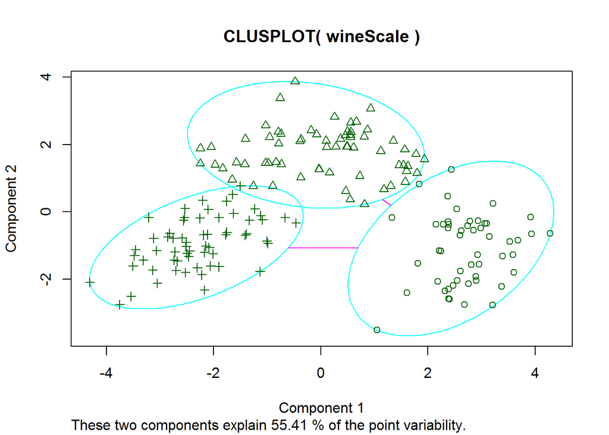

```r
library(cluster)
par(mfrow = c(1,1))
clusplot(wineScale, fit.km$cluster)
```

Without getting too detailed in the explanation, or not having drunk all the wines on the list, the visual representation of the fit seems to be quite good and separates the groups with minor overlap. There are 3 points that are right on the border of the left-most clusters that are most likely one set of poor clusterings. The other 3 may be right on the border of the right-most cluster.